# Validate that scanBit Correctly Identifies Tumor Cells

Author

Matt Cannon and Matt Gust

Published

January 26, 2026

# Load in helper R functions

## Read in and preprocess raw data

```r
# species_pattern - either "", "^mm10---" or "^GRCh38-"

read_raw <- function(i,
                     samples_tsv,
                     species_pattern = "",
                     organism = NULL,
                     ncount_min = NA,
                     ncount_max = NA,
                     mt_percent_max = NA,
                     save_qs_dir = "output/seurat_objects/individual/",
                     h5_folder = "/home/gdrobertslab/lab/Counts_2/",
                     min_n_cells = 50,
                     annotate_ref,
                     annotate_labels,
                     annotate_species = "",
                     annotate_additional_ref,
                     annotate_additional_labels,
                     bam_file) {
    sample_name <- samples_tsv$Sample_ID[i]

    # Not making this an lapply as defaults are different, may do it later
    ncount_min <-
        pick_cutoff(
            ncount_min,
            samples_tsv$subset_nCount_RNA_min[i],
            0,
            species_pattern
        )
    ncount_max <-
        pick_cutoff(
            ncount_max,
            samples_tsv$subset_nCount_RNA_max[i],
            Inf,
            species_pattern
        )
    mt_percent_max <-
        pick_cutoff(
            mt_percent_max,
            samples_tsv$subset_percent.mt_max[i],
            100,
            species_pattern
        )

    path_h5 <-
        paste0(h5_folder, "/", sample_name, "/filtered_feature_bc_matrix.h5")

    counts <- tibble::tibble(sample_name = sample_name)

    if (!file.exists(path_h5)) {
        stop(paste(sample_name, "h5 file does not exist"))
    } else {
        sobj <-
            rrrSingleCellUtils::tenx_load_qc(
                h5_file = path_h5,
                species_pattern = species_pattern,
                violin_plot = FALSE
            )

        sobj$bam_file <- bam_file

        sobj$cell_barcode <- Seurat::Cells(sobj)

        pre_filt_hist <-
            rrrSingleCellUtils::feature_hist(
                sobj,
                features = c("nCount_RNA", "percent.mt"),
                cutoff_table = tibble::tibble(
                    feature = c("nCount_RNA", "percent.mt"),
                    min_val = c(ncount_min, mt_percent_max),
                    max_val = c(ncount_max, NA)
                )
            )

        counts$n_cells_pre_filter <- ncol(sobj)

        counts$n_cells_post_filter <-
            sobj@meta.data %>%
            as.data.frame() %>%
            filter(
                nCount_RNA > ncount_min &
                    nCount_RNA < ncount_max &
                    percent.mt < mt_percent_max
            ) %>%
            nrow()

        if (counts$n_cells_post_filter >= min_n_cells) {
            counts$kept <- TRUE
            sobj <-
                subset(
                    sobj,
                    nCount_RNA > ncount_min &
                        nCount_RNA < ncount_max &
                        percent.mt < mt_percent_max
                ) %>%
                rrrSingleCellUtils::process_seurat()

            opt_res <-
                rrrSingleCellUtils::optimize_silhouette(
                    sobj,
                    summary_plot = FALSE
                ) %>%
                dplyr::arrange(dplyr::desc(sil_vals)) %>%
                dplyr::pull(res_vals) %>%
                head(1)

            sobj <- Seurat::FindClusters(sobj, resolution = opt_res)

            sobj$individ_clusters <- sobj$seurat_clusters

            # Add metadata to Seurat object from samples_tsv
            for (colname in colnames(samples_tsv)) {
                sobj[[colname]] <- samples_tsv[[colname]][i]
            }

            # Annotate celltypes
            sobj <-
                rrrSingleCellUtils::annotate_celltypes(
                    sobj,
                    species = annotate_species,
                    ref = annotate_ref,
                    labels = annotate_labels,
                    add_ref = annotate_additional_ref,
                    add_labels = annotate_additional_labels,
                    aggr_ref = TRUE
                )

            dimplot_fig <-
                Seurat::DimPlot(
                    sobj,
                    group.by = c("individ_clusters", "cell_type"),
                    label = TRUE,
                    label.size = 2,
                    label.box = TRUE,
                    repel = TRUE,
                    ncol = 1
                ) +
                Seurat::NoLegend()

            ggplot2::ggsave(
                paste0(
                    "output/figures/qc_cutoffs/pre_filter_hist_",
                    sample_name,
                    dplyr::if_else(
                        organism == "",
                        "",
                        paste0("_", organism)
                    ),
                    ".pdf"
                ),
                patchwork::wrap_plots(
                    pre_filt_hist,
                    dimplot_fig,
                    ncol = 1,
                    heights = c(1, 5)
                ),
                width = 10,
                height = 20
            )

            qs::qsave(
                sobj,
                dplyr::if_else(
                    organism == "",
                    paste0(save_qs_dir, "/", sample_name, ".qs"),
                    paste0(save_qs_dir, "/", sample_name, "_", organism, ".qs")
                )
            )

            message(sample_name, " sobject made and saved")
        } else {
            counts$kept <- FALSE
            message(
                paste0(
                    sample_name,
                    " started with ",
                    ncol(sobj),
                    " cells but has ",
                    counts$n_cells_post_filter,
                    " cells left after filtering which is less than ",
                    min_n_cells,
                    " hence it was discarded"
                )
            )
        }
    }

    counts$median_ncount <-
        median(sobj$nCount_RNA)

    counts$mean_ncount <-
        mean(sobj$nCount_RNA)

    return(counts)
}

pick_cutoff <- function(arg_provided,
                        from_sample_tsv,
                        default,
                        species_pattern) {
    from_sample_tsv <- pull_species_cutoff(from_sample_tsv, species_pattern)
    if (is.na(arg_provided)) {
        if (is.na(from_sample_tsv)) {
            return(default)
        } else {
            return(from_sample_tsv)
        }
    } else {
        return(arg_provided)
    }
}

# Pull the cutoff value from the sample tsv data if it's in there
pull_species_cutoff <- function(from_sample_tsv,
                                species_pattern) {
    if (species_pattern != "") {
        if (!grepl(
            # we don't want the caret in the pattern for this
            stringr::str_remove(species_pattern, "^\\^"),
            from_sample_tsv
        )) {
            stop(
                "Species pattern provided but not found in from_sample_tsv. ",
                "Species_pattern: ",
                species_pattern,
                ". Cutoff info from sample sheet: ",
                from_sample_tsv
            )
        }
        cutoff <-
            stringr::str_match(
                from_sample_tsv,
                paste0(stringr::str_remove(species_pattern, "\\^"), "([0-9]+)")
            )[1, 2]
        return(as.numeric(cutoff))
    } else {
        # If from_sample_tsv has letters in it, species pattern likely there
        # We need to specify scientific = F so that 100,000 != 1e+05 which
        # has an "e" :-| and so fails here
        if (grepl("[a-zA-Z]", format(from_sample_tsv, scientific = FALSE)) &&
            !is.na(from_sample_tsv)) {
            stop(
                "Sample cutoff value is not just a number but species_pattern ",
                "not provided. Species_pattern: ",
                species_pattern,
                ". Cutoff from sample sheet: ",
                from_sample_tsv
            )
            # Otherwise it's either a number or NA
        } else {
            return(from_sample_tsv)
        }
    }
}
```

## Read raw from table of samples

```r
read_raw_from_table <- function(sample_table,
                                h5_folder,
                                min_n_cells = 1000,
                                organism,
                                annotate_species,
                                count_table_file,
                                bam_file,
                                annotate_additional_ref = list(),
                                annotate_additional_labels = list()) {
    count_table <- parallel::mclapply(
        seq_len(nrow(sample_table)),
        mc.preschedule = FALSE,
        mc.cores = parallelly::availableCores(),
        function(i) {
            read_raw(
                i = i,
                h5_folder = h5_folder,
                min_n_cells = min_n_cells,
                sample_table,
                organism = organism,
                annotate_species = annotate_species,
                bam_file =
                    paste0(
                        h5_folder,
                        "/",
                        sample_table$Sample_ID[i],
                        "/",
                        bam_file
                    ),
                annotate_additional_ref = annotate_additional_ref,
                annotate_additional_labels = annotate_additional_labels
            )
        }
    ) |>
        confirm_mclapply_worked() |>
        dplyr::bind_rows()

    readr::write_tsv(count_table, count_table_file)
}
```

```r
gsea_dotplot <- function(data, x_col = "z_score") {
    lab4plot <-
        tibble::tibble(
            y = c(-2.5, 2.5),
            x = c(0.2, 0.2),
            label = c("Downregulated", "Upregulated")
        )

    plot_name <-
        ggplot2::ggplot() +
        ggplot2::geom_point(
            data = data,
            ggplot2::aes(
                x = -1 * order,
                y = get(x_col),
                color = -log10(padj),
                size = size
            ),
            stat = "identity",
            alpha = 0.8
        ) +
        ggplot2::coord_flip() +
        ggplot2::geom_text(
            data = data, # text for pathways names
            aes(
                x = -1 * order,
                y = get(x_col) + (y_pos * 5),
                hjust = justify_y,
                label = pathway
            ),
            size = 2,
            fontface = "bold"
        ) +
        geom_text(
            data = lab4plot, # text for upregulated/downregulated
            aes(
                x = x,
                y = y,
                label = label
            ),
            fontface = "bold",
            size = 2.5
        ) +
        ggplot2::scale_fill_manual(
            values = rrrSingleCellUtils::plot_cols,
            name = paste0(x_col, " > 0")
        ) +
        ggplot2::theme(
            strip.background = ggplot2::element_rect(
                color = "white",
                fill = "white"
            ),
            panel.grid.major = ggplot2::element_blank(),
            panel.grid.minor = ggplot2::element_blank(),
            panel.border = ggplot2::element_blank(),
            axis.line.x = ggplot2::element_line(color = "black"),
            axis.line.y = ggplot2::element_blank(),
            axis.title.x = ggplot2::element_text(size = 7),
            axis.ticks.y = ggplot2::element_blank(),
            plot.title = ggplot2::element_text(size = 7, face = "bold"),
            axis.text.y = ggplot2::element_blank(),
            axis.text.x = ggplot2::element_text(size = 7),
            legend.title = ggplot2::element_text(size = 7, face = "bold")
        ) +
        ggplot2::labs(
            title = data$sample[1],
            y = "NES",
            x = ""
        ) +
        ggplot2::theme(plot.title = ggplot2::element_text(hjust = 0.5)) +
        ggplot2::ylim(-6, 6) +
        ggplot2::scale_color_gradient(low = plot_cols[2], high = plot_cols[1])

    return(plot_name)
}
```

## Confirm that we have HDF5 available

```r
#' Check for HDF5 File Support
#'
#' This function checks for the availability of HDF5 file support in the current R environment.
#'
#' @return Logical value indicating whether HDF5 support is available.
hdf5_check <- function() {
    h5_return <-
        suppressWarnings(
            try(
                system(
                    "which h5pfc",
                    intern = TRUE,
                    ignore.stderr = TRUE
                )
            )
        ) |>
            length() > 0
    if (!h5_return) {
        stop(
            "\nYou need to have h5pfc installed to read in h5_files. ",
            "Perhaps ml load HDF5 before you start R?\n"
        )
    }
}
```

## Confirm that Seurat version installed is > 5

```r
#' Check Seurat Version
#'
#' This function checks the version of the Seurat package installed in the R environment.
#' It ensures that the correct version of Seurat is being used for downstream analysis.
#'
#' @return A message indicating the version of Seurat installed.
seurat_version_check <- function() {
    if (packageVersion("Seurat") < "5.0.0") {
        stop(
            "Please install Seurat version 5.0.0 or higher. ",
            "You are currently using version ",
            packageVersion("Seurat")
        )
    }
}
```

```r
#' Confirm mclapply Worked And Dump Error Messages If Not
#'
#' This function checks if the `mclapply` function executed successfully on the provided input list.
#'
#' @param input_list A list that was processed by `mclapply`.
#' @return The input list if `mclapply` was successful or the error messages if it failed.
confirm_mclapply_worked <- function(input_list) {
    if (length(input_list) == 0) {
        stop("Empty input list")
    }

    has_error <- FALSE
    for (item in input_list) {
        if (inherits(item, "try-error")) {
            warning("mclapply failed with error: ", item[[1]])
            has_error <- TRUE
        }
    }

    if (has_error) {
        stop("mclapply failed")
    } else {
        return(input_list)
    }
}
```

## Plotting Functions

```r
dimplot_better <- function(object,
                           group_by = NULL,
                           cols,
                           ncol = 1,
                           label_size = 2.5,
                           split_by = NULL,
                           ...) {
    Seurat::DimPlot(
        object,
        group.by = group_by,
        split.by = split_by,
        ncol = ncol,
        label.size = label_size,
        label = TRUE,
        repel = TRUE,
        shuffle = TRUE,
        label.box = TRUE,
        cols = c(rrrSingleCellUtils::plot_cols, sample(rainbow(1000))),
        ...
    ) +
        ggplot2::coord_fixed()
}
```

## Samples for downsample analysis

```r
filter_cells_umi_cutoff <- function(sobj, max_umi) {
    keep_cells <-
        sobj |>
        SeuratObject::FetchData(vars = c(
            "cell_group",
            "cell_barcode",
            "bam_file",
            "nCount_RNA"
        )) |>
        tibble::as_tibble() |>
        dplyr::group_by(cell_group) |>
        dplyr::arrange(cell_group, cell_barcode) |>
        dplyr::mutate(cumsum = cumsum(nCount_RNA)) |>
        dplyr::filter(cumsum < max_umi) |>
        dplyr::pull(cell_barcode)

    sobj_sub <- subset(sobj, cells = keep_cells)
    return(sobj_sub)
}

filter_cells_n_cell_cutoff <- function(sobj, n_cells) {
    set.seed(1337)
    sobj <- subset(sobj, downsample = n_cells)

    return(sobj)
}

make_cbt <- function(sobj, cutoff, downsample_type) {
    if (downsample_type == "max_umi") {
        sub_sobj <- filter_cells_umi_cutoff(sobj, cutoff)
    } else if (downsample_type == "n_cells") {
        sub_sobj <- filter_cells_n_cell_cutoff(sobj, cutoff)
    } else {
        stop("Must provide either max_umi or n_cells as downsample type")
    }

    cell_barcode_group_table <-
        sub_sobj |>
        SeuratObject::FetchData(vars = c(
            "cell_group",
            "cell_barcode",
            "bam_file",
            "nCount_RNA"
        )) |>
        tibble::as_tibble() |>
        dplyr::arrange(cell_group)

    return(cell_barcode_group_table)
}

scanbit_downsample_loop <- function(sobj,
                                    cutoff_vector,
                                    out_dir_base,
                                    sample_label,
                                    min_read_depth = 5,
                                    min_snvs_per_cluster = 10,
                                    downsample_type = "n_cells",
                                    keep_temp_dir = FALSE,
                                    ploidy,
                                    ref_fasta) {
    parallel::mclapply(
        cutoff_vector,
        mc.cores = 10,
        mc.preschedule = FALSE,
        function(cutoff) {
            out_dir <-
                file.path(
                    out_dir_base,
                    paste0(
                        "downsample_",
                        sprintf("%.0f", cutoff),
                        "_cells"
                    )
                )

            dir.create(
                out_dir,
                recursive = TRUE,
                showWarnings = FALSE
            )

            if (keep_temp_dir) {
                temp_dir <- file.path(out_dir_base, "tempdir")
                cleanup <- FALSE
            } else {
                temp_dir <- tempfile(
                    pattern = paste0(
                        "tempdir_",
                        cutoff,
                        sample_label
                    )
                )
                cleanup <- TRUE
            }

            # Get the cell barcodes for the current cutoff
            cell_barcode_group_table <-
                make_cbt(
                    sobj,
                    cutoff = cutoff,
                    downsample_type = downsample_type
                )

            readr::write_tsv(
                cell_barcode_group_table,
                file.path(
                    out_dir,
                    paste0(
                        "cell_barcode_table_",
                        sample_label,
                        "_",
                        sprintf("%.0f", cutoff),
                        "_cells.txt"
                    )
                )
            )

            cell_barcode_group_table <-
                dplyr::select(cell_barcode_group_table, -nCount_RNA)

            scanBit::get_snp_tree(
                cellid_bam_table = cell_barcode_group_table,
                ploidy = ploidy,
                temp_dir = temp_dir,
                output_dir = out_dir,
                output_base_name = paste0(
                    "downsample_",
                    sample_label,
                    "_",
                    sprintf("%.0f", cutoff)
                ),
                ref_fasta = ref_fasta,
                min_depth = min_read_depth,
                job_base = "downsample_cells",
                min_snvs_per_cluster = min_snvs_per_cluster,
                n_bootstraps = 10000,
                max_prop_missing_at_site = 0.9,
                cleanup = cleanup,
                tree_image_type = "pdf",
                other_job_header_options = c(
                    "--time=8:00:00",
                    "--partition=himem,general"
                ),
                other_batch_options = c(
                    "ml purge",
                    "ml miniforge3",
                    'eval "$(conda shell.bash hook)"'
                ),
            )
        }
    )
}
```

## Helper function to run scanbit

This asssumes a bunch of things about the structure of this project ::: {.cell}

```r
scanbit_one_sample <- function(this_sample,
                               species,
                               ploidy,
                               ref_fasta,
                               out_dir) {
    sobj <-
        qs::qread(paste0(
            "output/seurat_objects/individual/",
            this_sample,
            "_",
            species,
            ".qs"
        ))

    sobj$cell_group <-
        paste0(
            sobj$cluster_label,
            "_c",
            sobj$individ_clusters
        )

    cell_barcode_group_table <-
        sobj@meta.data |>
        dplyr::select(cell_group, cell_barcode, bam_file) |>
        dplyr::as_tibble()

    job_worked <-
        scanBit::get_snp_tree(
            cellid_bam_table = cell_barcode_group_table,
            ploidy = ploidy,
            output_dir = out_dir,
            temp_dir = paste0("/gpfs0/scratch/mvc002/scanbit/", this_sample),
            output_base_name = paste0("snvs_", this_sample),
            ref_fasta = ref_fasta,
            min_depth = c(5, 10, 20, 30),
            job_base = paste0("sb_", this_sample),
            log_base = paste0("slurmOut/snv_", this_sample),
            min_snvs_per_cluster = 200,
            n_bootstraps = 10000,
            max_prop_missing_at_site = 0.9,
            tree_image_type = "pdf",
            cleanup = TRUE,
            other_job_header_options = c(
                "--time=8:00:00",
                "--partition=himem,general"
            ),
            other_batch_options = c(
                "ml purge",
                "ml miniforge3",
                'eval "$(conda shell.bash hook)"'
            ),
        )

    return(job_worked)
}
```

:::

```r
#' ggsave_wrap
#'
#' A wrapper function for saving a single ggplot object in multiple file formats at once.
#'
#' This function simplifies the process of saving a ggplot object by allowing the user
#' to specify multiple file formats and save the plot in all of them with a single call.
#'
#' @param file_stub The base file name (without extension) to use for saving the plot.
#' @param file_types A character vector of file extensions (e.g., c(".png", ".pdf")).
#' @param plot_variable The ggplot object to be saved.
#' @param width The width of the saved plot.
#' @param height The height of the saved plot.
#'
#' @return The function does not return a value but saves the plot to the specified files.
#'
#' @examples
#' # Example usage:
#' # ggsave_wrap("my_plot", c(".png", ".pdf"), my_plot, width = 6, height = 4)
#'
#' @export
ggsave_wrap <- function(
    file_stub,
    file_types,
    plot_variable,
    width,
    height
) {
    files_made <-
        lapply(
            file_types,
            function(x) {
                ggplot2::ggsave(
                    paste0(file_stub, ".", x),
                    plot_variable,
                    width = width,
                    height = height
                )
            }
        )
}
```

# Set up directory structure

```bash
for directoryName in \
    /gfpf0/scratch/mvc002/scanbit \
    input/10x_flex \
    output \
    slurmOut \
    output/counts \
    output/degs \
    output/gsea \
    output/refs \
    output/figures \
    output/figures/qc_cutoffs \
    output/figures/transgene \
    output/figures/shared_sites \
    output/seurat_objects/individual \
    output/seurat_objects/merged \
    output/downsample/scanbit_out \
    output/downsample/scanbit_out/geo_samples/ \
    output/read_depth/depths/bcf_depth \
    output/read_depth/depths/call_count \
    output/read_depth/scanbit_out/geo_samples \
    output/read_depth/depths \
    output/read_depth/shared \
    output/snv/tumor/x3 \
    output/snv/human/ \
    output/snv/flex \
    output/snv/mouse \
    output/snv/transgene/ \
    output/snv_processing/norm_mouse/ \
    output/snv_processing/transgene \
    output/snv_processing/F420_K7M2 \
    output/flex/var_counts_d1 \
    input \
    input/fastqs \
    custom_ref
do
    if [ ! -d ${directoryName} ]
    then
        mkdir -p ${directoryName}
    fi
done
```

```
mkdir: cannot create directory ‘/gfpf0’: Permission denied
```

## Check required software is available

```r
hdf5_check()

seurat_version_check()
```

# For these analysis we are going to do some key validations and analyses.

- Run variant calling on 10x flex data to quantify the sequencing error rate at varying read depths.
  - Data from https://www.10xgenomics.com/datasets/40k-mixture-of-cells-dissociated-from-4-fixed-mouse-tissues-using-manual-dissociation-multiplexed-samples-4-probe-barcodes-1-standard
- Analyze samples where the tumor cells express a marker that allows us to know which cells should be called as tumor and then assess accuracy of the method.
  - S0105 - K7M2-RFP tibia tumor
  - S0122 - K7M2 sLPmCherry lung mets 10 days post injection. Flow sorted Cherry positive fraction 1:1:1 mix of CD45+, Epcam+ and double negative
  - GSE247228 - lentiviral green fluorescent protein (GFP) in melanoma cells
  - GSE201615 - Cas9 in soft-tissue sarcoma cells, also dsRED
  - S0260 - barcoded F420 tumor samples
  - S0261 - barcoded F420 tumor sample
- Analyze samples from genetically distinct mouse strains where we know how the clustering should look.
  - S0066 - B6 lung
  - S0074 - Balb/c lung
- Analyze mouse OS models where the tumor cells derive from the host mouse strain to simulate a genetic divergence more expected in patients.
  - S0066 - (control) B6 lung
  - S0067 - B6, F420 injected, lungs from ROB 273 A, B, D; Epcam postive:negative 1:1
  - S0068 - B6, F420 injected, lungs from ROB 273E and ROB 274A; Epcam postive:negative 1:1
  - S0074 - (control) Balb/c lung
  - S0075 - Balb/c, K7M2 injected, lungs; Epcam postive:negative 1:1
  - S0105 - K7M2-RFP tibia tumor
  - S0200 - (control) F420 cellculture p17
  - S0201 - (control) K7M2 cellculture p17
  - S0246 - F420 lung mets and niche cells ctrl
  - S0259 - (control) F420, barcoded, preinjection t0 ctrl
  - S0260 - barcoded F420 tumor samples
  - S0261 - barcoded F420 tumor sample
- Assess scanBit results when run on human patient tumor samples.
  - GSE152048 OS samples
  - GSE162454 OS samples
  - GSE210358 prostate cancer samples
  - GSE222703 renal cell carcinoma samples
  - GSE169396 bone samples
  - GSE237579 healthy PBMC samples

# Download raw data from GEO/SRA, process it and re-align Roberts lab data to GFP/RFP reference

This also downloads the flex data from 10x

The output here will be cellrange counts folders in output/cellranger_out/

## Get FASTQ Files for GEO samples

```bash
n_geo_samples=$(grep -v geo_id misc/validation_geo_metadata.tsv | wc -l)

n_geo_samples=$((n_geo_samples - 1))

sbatch --array=0-${n_geo_samples}%20 sbatchCmds/get_geo_fastqs.sh
```

## Next, run cellranger count on the raw data from GEO

```bash
n_samples=($( \
    cut -f 3,8 misc/validation_geo_metadata.tsv \
    | uniq \
    | grep -v Sample_ID \
    | wc -l \
))

# since the array will start at zero
n_samples=$((n_samples - 1))

sbatch --array=0-${n_samples} sbatchCmds/count_geo.sh
```

## Delete the GEO fastqs to save space

```bash
rm input/othertumors/fastqs/G*/*.fastq.gz
```

## Make up the fastqs for the data from our lab

```bash
sbatch sbatchCmds/make_Roberts_fastqs.sh
```

## Run cellranger count on these samples

These are aligned to the new reference with gfp/rfp ::: {.cell}

```bash
sbatch sbatchCmds/count_roberts_gfp_rfp_mm10.sh
```

:::

## Delete the Roberts fastqs since we’re done with those

```bash
rm input/fastqs/S0*/*fastq.gz
```

## Get 10x flex data

```bash
sbatch sbatchCmds/get10x_flex.sh
```

# Read in raw data and process to Seurat objects

The metadata for all samples is stored in misc/sample_metadata.tsv.

Note that in the sample_metadata, for samples with multiple references, the cutoff format is “GRCh38-40000;mm10—20000” where the species_pattern is at the beginning of the string, followed by the cutoff value (no dash or anything). This is split from the second cutoff value by a semicolon. If there is only one reference, just use the cutoff value, no species pattern is needed.

## Read metadata, read data and make prepreocessed seurat objects

Load in Seurat objects and save individual qs objects off to disk

## Read in F420 and K7M2 samples to use as SingleR references

```r
read_raw_from_table(
    sample_table = read_tsv(
        "misc/mouse_samples_Roberts_metadata.tsv",
        show_col_types = FALSE
    ) %>%
        filter(Tissue == "cell culture"),
    h5_folder = "/home/gdrobertslab/lab/Counts_2/",
    organism = "mouse",
    annotate_species = "mouse",
    count_table_file = "output/counts/mouse_culture_cell_counts.txt",
    bam_file = "possorted_genome_bam.bam"
)
```

### Table of cell culture mouse cell counts per sample

```r
DT::datatable(read_tsv("output/counts/mouse_culture_cell_counts.txt"))
```

|  | sample_name | n_cells_pre_filter | n_cells_post_filter | kept | median_ncount | mean_ncount |
| --- | --- | --- | --- | --- | --- | --- |
| 1 | S0200 | 9049 | 9013 | True | 22644 | 25017.27748807278 |
| 2 | S0201 | 7960 | 7920 | True | 20937 | 23622.07537878788 |

## Prep known tumor cells to add to SingleR ref

```r
culture_ref_samples <-
    read_tsv(
        "misc/mouse_samples_Roberts_metadata.tsv",
        show_col_types = FALSE
    ) %>%
    filter(Tissue == "cell culture") %>%
    pull(Sample_ID)

tumor_refs <-
    lapply(
        culture_ref_samples,
        function(x) {
            set.seed(1337)
            sobj <- qs::qread(paste0(
                "output/seurat_objects/individual/",
                x,
                "_mouse.qs"
            )) %>%
                subset(downsample = 500)

            return(
                list(
                    sce = as.SingleCellExperiment(sobj),
                    labels = rep("Tumor", ncol(sobj))
                )
            )
        }
    )

qs::qsave(tumor_refs, "output/refs/mouse_tumor_refs.qs")
```

## Read in B6, Balbc, F420 and K7M2 samples

```r
tumor_refs <- qs::qread("output/refs/mouse_tumor_refs.qs")

read_raw_from_table(
    sample_table = read_tsv(
        "misc/mouse_samples_Roberts_metadata.tsv",
        show_col_types = FALSE
    ) %>%
        filter(Tissue != "cell culture"),
    h5_folder = "/home/gdrobertslab/lab/Counts_2/",
    organism = "mouse",
    annotate_species = "mouse",
    count_table_file = "output/counts/mouse_cell_counts.txt",
    bam_file = "possorted_genome_bam.bam",
    annotate_additional_ref = lapply(
        tumor_refs,
        function(x) x$sce
    ),
    annotate_additional_labels = lapply(
        tumor_refs,
        function(x) x$labels
    )
)
```

### Table of mouse cell counts per sample

```r
DT::datatable(read_tsv("output/counts/mouse_cell_counts.txt"))
```

|  | sample_name | n_cells_pre_filter | n_cells_post_filter | kept | median_ncount | mean_ncount |
| --- | --- | --- | --- | --- | --- | --- |
| 1 | S0066 | 9418 | 9275 | True | 12297 | 15716.45412398922 |
| 2 | S0067 | 8779 | 8520 | True | 14586 | 17845.1926056338 |
| 3 | S0068 | 16327 | 16150 | True | 12859 | 14865.06972136223 |
| 4 | S0074 | 9472 | 9423 | True | 7337 | 10092.95362411122 |
| 5 | S0075 | 12929 | 12795 | True | 11098 | 17564.13200468933 |
| 6 | S0246 | 10598 | 10519 | True | 7545 | 8612.341572392814 |
| 7 | S0260 | 5295 | 5237 | True | 5034 | 12910.20431544778 |
| 8 | S0261 | 5912 | 5815 | True | 5687 | 14147.20240756664 |

## Read in Robert’s lab data that was re-aligned

```r
tumor_refs <- qs::qread("output/refs/mouse_tumor_refs.qs")

read_raw_from_table(
    sample_table = read_tsv(
        "misc/mouse_samples_Roberts_realign_metadata.tsv",
        show_col_types = FALSE
    ),
    h5_folder = "output/cellranger_out",
    organism = "mouse",
    annotate_species = "mouse",
    count_table_file = "output/counts/mouse_cell_counts.txt",
    bam_file = "possorted_genome_bam.bam",
    annotate_additional_ref = lapply(
        tumor_refs,
        function(x) x$sce
    ),
    annotate_additional_labels = lapply(
        tumor_refs,
        function(x) x$labels
    )
)
```

### Table of mouse cell counts per sample

```r
DT::datatable(read_tsv("output/counts/mouse_cell_counts.txt"))
```

|  | sample_name | n_cells_pre_filter | n_cells_post_filter | kept | median_ncount | mean_ncount |
| --- | --- | --- | --- | --- | --- | --- |
| 1 | S0122 | 1294 | 1231 | True | 19242 | 21013.61738424045 |
| 2 | S0123 | 1844 | 1821 | True | 8210 | 9246.355299286106 |

## Mouse flex data from 10x

```r
read_raw_from_table(
    sample_table = read_tsv(
        "misc/flex_metadata.tsv",
        show_col_types = FALSE
    ),
    h5_folder = "input/10x_flex",
    organism = "mouse",
    annotate_species = "mouse",
    count_table_file = "output/counts/mouse_cell_counts_flex.txt",
    bam_file = "count_sample_alignments.bam"
)
```

### Table of 10x flex cell counts per sample

```r
DT::datatable(read_tsv("output/counts/mouse_cell_counts_flex.txt"))
```

|  | sample_name | n_cells_pre_filter | n_cells_post_filter | kept | median_ncount | mean_ncount |
| --- | --- | --- | --- | --- | --- | --- |
| 1 | flex_eye | 14134 | 13871 | True | 5216 | 9037.16379496792 |
| 2 | flex_intestine | 8181 | 8044 | True | 4828 | 9353.697041273 |
| 3 | flex_ovary | 10108 | 10042 | True | 7496.5 | 12979.20533758215 |
| 4 | flex_stomach | 7976 | 7826 | True | 6990.5 | 16824.15052389471 |

## Make Seurat objects from human GEO data

```r
read_raw_from_table(
    sample_table = read_tsv(
        "misc/validation_geo_metadata.tsv",
        show_col_types = FALSE
    ) %>%
        filter(
            sample_group == "tumor validation" |
                sample_group == "healthy samples"
        ) %>%
        select(-sra_number, -fake_lane) %>%
        distinct(),
    h5_folder = "output/cellranger_out",
    organism = "human",
    annotate_species = "human",
    count_table_file = "output/counts/human_geo_cell_counts.txt",
    bam_file = "possorted_genome_bam.bam"
)
```

## Table of GEO human cell counts per sample

```r
DT::datatable(read_tsv("output/counts/human_geo_cell_counts.txt"))
```

|  | sample_name | n_cells_pre_filter | n_cells_post_filter | kept | median_ncount | mean_ncount |
| --- | --- | --- | --- | --- | --- | --- |
| 1 | G0001 | 5838 | 5767 | True | 9129 | 12043.17426738339 |
| 2 | G0002 | 6066 | 5975 | True | 8413 | 11383.58811715481 |
| 3 | G0003 | 13741 | 13606 | True | 5368.5 | 8218.597236513302 |
| 4 | G0004 | 9461 | 9159 | True | 4971 | 7318.761764384758 |
| 5 | G0013 | 7308 | 7143 | True | 17412 | 23822.68556628867 |
| 6 | G0014 | 7588 | 7440 | True | 12949 | 17991.30174731183 |
| 7 | G0015 | 9110 | 8994 | True | 10179.5 | 11276.68278852568 |
| 8 | G0016 | 4050 | 3994 | True | 16880 | 23264.66249374061 |
| 9 | G0017 | 9954 | 9707 | True | 10634 | 14212.48779231482 |
| 10 | G0018 | 9181 | 9061 | True | 7827 | 14449.97240922636 |

[output cut: 28 more lines]

## Get data from GEO mouse data

```r
read_raw_from_table(
    sample_table = read_tsv(
        "misc/validation_geo_metadata.tsv",
        show_col_types = FALSE
    ) %>%
        filter(sample_group == "truthset validation") %>%
        select(-sra_number, -fake_lane) %>%
        distinct(),
    h5_folder = "output/cellranger_out",
    organism = "mouse",
    annotate_species = "mouse",
    count_table_file = "output/counts/mouse_geo_cell_counts_geo.txt",
    bam_file = "possorted_genome_bam.bam"
)
```

### Table of GEO mouse data

```r
DT::datatable(read_tsv("output/counts/mouse_geo_cell_counts_geo.txt"))
```

|  | sample_name | n_cells_pre_filter | n_cells_post_filter | kept | median_ncount | mean_ncount |
| --- | --- | --- | --- | --- | --- | --- |
| 1 | G0005 | 2003 | 1982 | True | 8752.5 | 12689.12058526741 |
| 2 | G0006 | 2612 | 2572 | True | 10024 | 15933.20800933126 |
| 3 | G0007 | 1880 | 1839 | True | 13688 | 20364.53670473083 |
| 4 | G0008 | 2169 | 2144 | True | 15544.5 | 18107.50279850746 |
| 5 | G0009 | 1828 | 1803 | True | 12850 | 16195.74653355519 |
| 6 | G0010 | 1698 | 1677 | True | 14344 | 15736.27847346452 |
| 7 | G0011 | 9489 | 9440 | True | 4406 | 7554.421822033898 |
| 8 | G0012 | 8400 | 8361 | True | 5821 | 9002.45544791293 |

# Run scanBit on the Seurat objects

## Prep the flex data

We’re going to run scanBit on a merged object for this so the data all ends up in one BCF file. ::: {.cell}

```r
flex_samples <-
    read_tsv("misc/flex_metadata.tsv", show_col_types = FALSE) %>%
    pull(Sample_ID)

flex_sobj_list <-
    lapply(
        flex_samples,
        function(this_sample) {
            qs::qread(paste0(
                "output/seurat_objects/individual/",
                this_sample,
                "_mouse.qs"
            ))
        }
    )

merged_flex <-
    merge(flex_sobj_list[[1]], flex_sobj_list[-1]) %>%
    process_seurat()

merged_flex$cell_group <-
    paste0(
        merged_flex$cluster_label,
        "_c",
        merged_flex$individ_clusters
    )

flex_dimplot <-
    (DimPlot(
        merged_flex,
        group.by = "Name",
        label = TRUE,
        label.box = TRUE,
        label.size = 2,
        repel = TRUE,
        ncol = 1
    ) +
        NoLegend()) +
    (DimPlot(
        merged_flex,
        group.by = "cell_group",
        label = TRUE,
        label.box = TRUE,
        label.size = 2,
        repel = TRUE,
        ncol = 1
    ) +
        NoLegend()) +
    (DimPlot(
        merged_flex,
        group.by = "cell_type",
        label = TRUE,
        label.box = TRUE,
        label.size = 2,
        repel = TRUE,
        ncol = 1
    ) +
        NoLegend())

ggsave(
    "output/figures/dimplot_flex_cell_type_group.pdf",
    flex_dimplot,
    width = 10,
    height = 20
)

flex_cell_barcode_group_table <-
    merged_flex@meta.data %>%
    select(cell_group, cell_barcode, bam_file) %>%
    as_tibble()
```

:::

## Run scanBit on the flex data

```r
# This was erroring out because there aren't enough snvs
# I lowered min_snvs_per_cluster to 5 to try to get it to work
snp_tree <-
    get_snp_tree(
        cellid_bam_table = flex_cell_barcode_group_table,
        ploidy = "mm10",
        output_dir = "output/snv/flex/",
        temp_dir = "output/snv/flex/tempdir",
        output_base_name = "flex_snvs",
        ref_fasta = "/reference/mus_musculus/mm10/ucsc_assmebly/illumina_download/Sequence/WholeGenomeFasta/genome.fa",
        min_depth = c(1, 5, 10, 20, 30),
        job_base = "flex_sbatch",
        log_base = "slurmOut/flex_snv",
        min_snvs_per_cluster = 5,
        n_bootstraps = 10000,
        max_prop_missing_at_site = 0.9,
        tree_image_type = "pdf",
        cleanup = FALSE,
        other_job_header_options = c(
            "--time=8:00:00",
            "--partition=himem,general"
        ),
        other_batch_options = c(
            "ml purge",
            "ml miniforge3",
            'eval "$(conda shell.bash hook)"'
        ),
    )
```

## Prep the mouse samples to run scanBit

We’re going to merge all of these data together so the output is one big tree. We’ll break it down further later on. ::: {.cell}

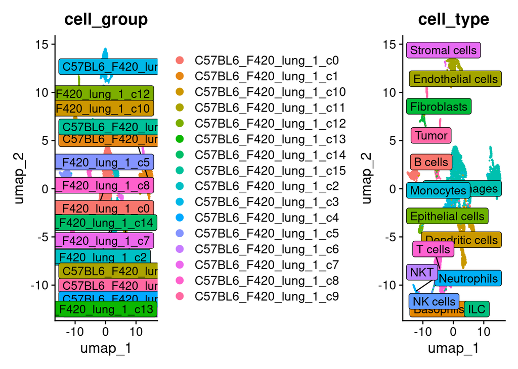

```r
mouse_samples <-
    read_tsv(
        "misc/mouse_samples_Roberts_metadata.tsv",
        show_col_types = FALSE
    ) %>%
    pull(Sample_ID) %>%
    c(
        read_tsv(
            "misc/mouse_samples_Roberts_realign_metadata.tsv",
            show_col_types = FALSE
        ) %>%
            pull(Sample_ID)
    )

mouse_sobj_list <-
    lapply(
        mouse_samples,
        function(this_sample) {
            qs::qread(paste0(
                "output/seurat_objects/individual/",
                this_sample,
                "_mouse.qs"
            ))
        }
    )
names(mouse_sobj_list) <- mouse_samples

# With the clustering I did initially, S0067 had a cluster that was roughly
# 50/50 tumor normal and it messes up the whole F420/B6 tree
# This is a good example of how important good clustering is to get this to work
# I renamed the original tree plots with _orig.pdf to maybe show in supplement
# Reclustering so this mixed cluster is split fixes the issue

mouse_sobj_list$S0067 <-
    mouse_sobj_list$S0067 %>%
    process_seurat(resolution = 0.25)

mouse_sobj_list$S0067$individ_clusters <- mouse_sobj_list$S0067$seurat_clusters
mouse_sobj_list$S0067$cell_group <-
    paste0(
        mouse_sobj_list$S0067$cluster_label,
        "_c",
        mouse_sobj_list$S0067$individ_clusters
    )

DimPlot(
    mouse_sobj_list$S0067,
    group.by = c("cell_group", "cell_type"),
    label = TRUE,
    label.box = TRUE,
    repel = TRUE
) +
    NoLegend()
```

```r
merged_mouse <-
    merge(mouse_sobj_list[[1]], mouse_sobj_list[-1]) %>%
    process_seurat()

merged_mouse$cell_group <-
    paste0(
        merged_mouse$cluster_label,
        "_c",
        merged_mouse$individ_clusters
    )

qs::qsave(merged_mouse, "output/seurat_objects/merged/merged_mouse.qs")

mouse_cell_barcode_group_table <-
    merged_mouse@meta.data %>%
    select(cell_group, cell_barcode, bam_file) %>%
    as_tibble()
```

:::

## Run scanBit on the mouse data from our lab

```r
snp_tree <-
    get_snp_tree(
        cellid_bam_table = mouse_cell_barcode_group_table,
        ploidy = "mm10",
        output_dir = "output/snv/mouse/",
        temp_dir = "output/snv/mouse/tempdir",
        output_base_name = "mouse_snvs",
        ref_fasta = "/reference/mus_musculus/mm10/ucsc_assmebly/illumina_download/Sequence/WholeGenomeFasta/genome.fa",
        min_depth = c(5, 10, 20, 30),
        job_base = "mouse_sbatch",
        log_base = "slurmOut/mouse_snv",
        min_snvs_per_cluster = 200,
        n_bootstraps = 10000,
        max_prop_missing_at_site = 0.9,
        tree_image_type = "pdf",
        cleanup = TRUE,
        other_job_header_options = c(
            "--time=8:00:00",
            "--partition=himem,general"
        ),
        other_batch_options = c(
            "ml purge",
            "ml miniforge3",
            'eval "$(conda shell.bash hook)"'
        )
    )
```

## Prep the mouse samples with GFP/RFP

```r
transgene_samples <-
    read_tsv(
        "misc/validation_geo_metadata.tsv",
        show_col_types = FALSE
    ) %>%
    filter(sample_group == "truthset validation") %>%
    pull(Sample_ID) %>%
    unique()

roberts_transgene_samples <-
    read_tsv(
        "misc/mouse_samples_Roberts_realign_metadata.tsv",
        show_col_types = FALSE
    ) %>%
    pull(Sample_ID)

ltbc_transgene_samples <- c("S0260", "S0261")

transgene_samples <- c(
    transgene_samples,
    roberts_transgene_samples,
    ltbc_transgene_samples
)

samples_worked <-
    parallel::mclapply(
        transgene_samples,
        mc.cores = 5,
        mc.preschedule = FALSE,
        function(this_sample) {
            scanbit_one_sample(
                this_sample = this_sample,
                species = "mouse",
                ploidy = "mm10",
                ref_fasta = "custom_ref/gfp_rfp_mm10/fasta/genome.fa",
                out_dir = "output/snv/transgene/"
            )
        }
    )
names(samples_worked) <- transgene_samples

print(samples_worked)
```

```
$G0005
[1] TRUE

$G0006
[1] TRUE

$G0007
[1] TRUE

$G0008
[1] TRUE

$G0009
[1] TRUE

$G0010
[1] TRUE

$G0011
[1] TRUE

$G0012
[1] TRUE

$S0122
[1] TRUE

$S0123
[1] TRUE

$S0260
[1] TRUE

$S0261
[1] TRUE
```

## Run scanBit on the human samples

Doing these individually ::: {.cell}

```r
human_samples <-
    read_tsv(
        "misc/validation_geo_metadata.tsv",
        show_col_types = FALSE
    ) %>%
    filter(sample_group != "truthset validation") %>%
    pull(Sample_ID) %>%
    unique()

samples_worked <-
    parallel::mclapply(
        human_samples,
        mc.cores = 5,
        mc.preschedule = FALSE,
        function(this_sample) {
            scanbit_one_sample(
                this_sample = this_sample,
                species = "human",
                ploidy = "GRCh38",
                ref_fasta = "/home/gdrobertslab/lab/GenRef/10x-hg38/fasta/genome.fa",
                out_dir = "output/snv/human/"
            )
        }
    )
names(samples_worked) <- human_samples

print(samples_worked)
```

```
$G0001
[1] TRUE

$G0002
[1] TRUE

$G0003
[1] TRUE

$G0004
[1] TRUE

$G0013
[1] TRUE

$G0014
[1] TRUE

$G0015
[1] TRUE

$G0016
[1] TRUE

$G0017
[1] TRUE

$G0018
[1] TRUE

$G0019
[1] TRUE

$G0020
[1] TRUE

$G0021
[1] TRUE

$G0022
```

[output cut: 58 more lines]

```

$G0044
[1] TRUE

$G0045
[1] TRUE

$G0047
[1] TRUE

$G0048
[1] TRUE

$G0049
[1] TRUE
```

:::

# Run analysis on flex data to calculate accuracy

## Test snp calling on flex data

## Quantify the number of SNVs for each level of coverage

## Merge the bcf files from min depth of 1 from flex scanbit analysis

This keeps all the positions, not just those with an alt position

This requires that the `scanbit_run_flex` chunk has cleanup set to FALSE ::: {.cell}

```bash
# sbatch sbatchCmds/flex_merge_c1_all.sh
```

:::

### Count the total number of positions covered by flex data for each cluster

```bash
sbatch sbatchCmds/flex_count_vars.sh
```

```
Submitted batch job 7498692
```

### Count the total number of positions that include an alt in flex data

```bash
# sbatch sbatchCmds/count_alts.sh
```

### Calculate variant calling accuracy in flex data

Any mutation called in the flex data is almost certainly a PCR/sequencing error since this method uses probes. ::: {.cell}

```r
all_flex_files <-
    list.files(
        path = "output/flex/var_counts_d1",
        pattern = ".txt",
        full.names = TRUE
    )

# In the future, break this down by mt vs non-mt to see if the non-mt are the wierd inaccurate calls ~ 500 - 1000 depth
flex_accuracy <-
    read_tsv(
        all_flex_files,
        id = "sample",
        show_col_types = FALSE,
        col_names = c("chr", "alt", "depth", "count")
    ) %>%
    mutate(
        sample = basename(sample) %>%
            str_remove(".txt"),
        alt = if_else(
            alt == ".",
            "ref",
            "variant"
        )
    ) %>%
    group_by(sample, depth, alt) %>%
    summarize(count = sum(count, na.rm = TRUE), .groups = "drop") %>%
    group_by(sample, depth) %>%
    mutate(total_count = sum(count, na.rm = TRUE)) %>%
    ungroup() %>%
    pivot_wider(
        id_cols = c(sample, depth, total_count),
        names_from = "alt",
        values_from = "count",
        values_fill = 0
    ) %>%
    mutate(perc_wrong = variant / total_count * 100) %>%
    group_by(depth) %>%
    summarize(
        mean_total_count = mean(total_count, na.rm = TRUE),
        mean_perc_wrong = mean(perc_wrong, na.rm = TRUE),
        .groups = "drop"
    ) %>%
    filter(depth != 1)

write_tsv(
    flex_accuracy,
    "output/flex/flex_accuracy.txt"
)

accuracy_plot <-
    filter(flex_accuracy, depth <= 50) %>%
    ggplot(aes(x = depth, y = mean_perc_wrong / 100)) +
    #geom_smooth(alpha = 0.5) +
    geom_point() +
    # geom_text(
    #     data = filter(flex_accuracy, depth <= 10),
    #     aes(label = depth),
    #     nudge_y = 0.00001
    # ) +
    scale_y_continuous(labels = scales::label_percent()) +
    labs(
        title = "Percent Inaccurate Calls by Read Depth",
        x = "Read depth of variant calls",
        y = "% inaccurate variant calls"
    )

ggsave_wrap(
    "output/figures/flex_accuracy_scatterplot",
    file_type = c("png", "pdf"),
    plot_variable = accuracy_plot,
    width = 6,
    height = 4
)
```

:::

## Calculate how many positions covered to each depth by normal data

```r
all_flex_files <-
    list.files(
        path = "output/flex/var_counts_d1",
        pattern = ".txt",
        full.names = TRUE
    )

# In the future, break this down by mt vs non-mt to see if the non-mt are the weird inaccurate calls ~ 500 - 1000 depth
flex_accuracy <-
    read_tsv(
        all_flex_files,
        id = "sample",
        show_col_types = FALSE,
        col_names = c("chr", "alt", "depth", "count")
    ) %>%
    mutate(
        sample = basename(sample) %>%
            str_remove(".txt"),
        alt = if_else(
            alt == ".",
            "ref",
            "variant"
        )
    ) %>%
    group_by(sample, depth, alt) %>%
    summarize(count = sum(count, na.rm = TRUE), .groups = "drop") %>%
    group_by(sample, depth) %>%
    mutate(total_count = sum(count, na.rm = TRUE)) %>%
    ungroup() %>%
    pivot_wider(
        id_cols = c(sample, depth, total_count),
        names_from = "alt",
        values_from = "count",
        values_fill = 0
    ) %>%
    mutate(perc_wrong = variant / ref * 100) %>%
    group_by(depth) %>%
    summarize(
        mean_total_count = mean(total_count, na.rm = TRUE),
        mean_perc_wrong = mean(perc_wrong, na.rm = TRUE),
        .groups = "drop"
    ) %>%
    filter(depth != 1)

flex_accuracy %>%
    filter(depth <= 20) %>%
    gt::gt() %>%
    gt::cols_label(
        depth = gt::md("**Read depth**"),
        mean_total_count = gt::md("**Average covered bases**"),
        mean_perc_wrong = gt::md("**% inaccurate variant calls**")
    ) %>%
    gt::fmt_percent(
        columns = "mean_perc_wrong",
        scale_values = FALSE,
        decimals = 4
    ) %>%
    gt::fmt_number(columns = "mean_total_count") %>%
    gt::cols_align(
        align = "center"
    ) %>%
    gt::gtsave(
        filename = "output/figures/flex_accuracy_table.html"
    )
```

## Plot how many sites are covered at each depth

## Plot how many inaccurate variant calls we would expect at each depth

# Downsample GEO samples to one cell and quantify read depth coverage

## Run scanBit on individual cells with min_read_depth of 1 to use for read depth and accuracy analysis

For this I’m keeping ten individual cells per cluster, and each cell is assigned to its own cell_group so that I am calculating read depth data for many individual cells. ::: {.cell}

```r
samples_geo <-
    read_tsv("misc/validation_geo_metadata.tsv", show_col_types = FALSE) %>%
    filter(grepl("tumor validation|healthy samples", sample_group)) %>%
    pull(Sample_ID) %>%
    unique()

n_cell_cutoffs <- 1

# Keeping mc.cores low since each run submits 100+ jobs
output <-
    parallel::mclapply(
        samples_geo,
        mc.cores = 2,
        mc.preschedule = FALSE,
        function(this_sample) {
            sobj <-
                qs::qread(paste0(
                    "output/seurat_objects/individual/",
                    this_sample,
                    "_human.qs"
                ))

            sobj$cell_group <-
                paste0(
                    "clust_",
                    sobj$individ_clusters,
                    "_",
                    sobj$cell_barcode
                )

            Idents(sobj) <- sobj$individ_clusters
            set.seed(1337)
            sobj <- subset(sobj, downsample = 10)

            Idents(sobj) <-
                sobj$cell_group

            scanbit_downsample_loop(
                sobj,
                cutoff_vector = n_cell_cutoffs,
                min_read_depth = c(1, 2, 5, 10, 20),
                out_dir_base = file.path(
                    "output/read_depth/scanbit_out/geo_samples/",
                    this_sample
                ),
                keep_temp_dir = TRUE,
                sample_label = this_sample,
                ploidy = "GRCh38",
                ref_fasta = "/home/gdrobertslab/lab/GenRef/10x-hg38/fasta/genome.fa"
            )
        }
    )
```

:::

## Batch job to count site coverage of GEO human patient samples

This includes any site with coverage, not just variant calls ::: {.cell}

```bash
sbatch sbatchCmds/geo_bcf_depths.sh
```

```
Submitted batch job 7514675
```

:::

## Calculate stats on nCount_RNA for single cell data

```r
list.files(
    path = "output/read_depth/scanbit_out/geo_samples",
    pattern = "cell_barcode_table_.+_1_cells.txt",
    recursive = TRUE,
    full.names = TRUE
) %>%
    read_tsv(
        id = "sample",
        show_col_types = FALSE
    ) %>%
    summarize(
        mean_ncount = mean(nCount_RNA),
        median_ncount = median(nCount_RNA),
        min_ncount = min(nCount_RNA),
        max_ncount = max(nCount_RNA)
    ) %>%
    write_tsv("output/read_depth/ncount_summary.tsv")
```

## Calculate the # of positions covered where any cell has a variant

```r
all_var_files <-
    list.files(
        path = "output/read_depth/depths/bcf_depth",
        pattern = "variant_pos",
        full.names = TRUE
    )

var_depths <-
    read_tsv(
        all_var_files,
        id = "cell_sample",
        show_col_types = FALSE,
        skip_empty_rows = FALSE
    ) %>%
    mutate(
        cell_sample = basename(cell_sample) %>%
            str_remove("variant_pos_") %>%
            str_remove(".txt"),
        group = "Variant sites"
    )

ave_var_depths <-
    var_depths %>%
    pivot_wider(
        names_from = "depth",
        values_from = "count",
        values_fill = 0
    ) %>%
    pivot_longer(
        cols = c(-cell_sample, -group),
        names_to = "depth",
        values_to = "count"
    ) %>%
    group_by(depth) %>%
    summarize(
        mean_count_var = mean(count),
        median_count_var = median(count),
        se_count = sd(count) / sqrt(n()),
        .groups = "drop",
    ) %>%
    mutate(depth = as.numeric(depth)) %>%
    arrange(desc(depth)) %>%
    mutate(cum_count_var = cumsum(mean_count_var)) %>%
    arrange(depth)

write_tsv(
    ave_var_depths,
    "output/read_depth/n_var_count_summary.tsv"
)
```

## Compile all single-cell variant call depths

```r
all_depth_files <-
    list.files(
        path = "output/read_depth/depths/bcf_depth",
        pattern = "bcf_depth_G",
        full.names = TRUE
    )
all_depths <-
    read_tsv(
        all_depth_files,
        id = "cell_sample",
        show_col_types = FALSE,
    ) %>%
    mutate(
        cell_sample = basename(cell_sample) %>%
            str_remove("bcf_depth_") %>%
            str_remove(".txt"),
        group = "All sites"
    )

ave_depths <-
    all_depths %>%
    filter(depth != 1) %>%
    pivot_wider(
        names_from = "depth",
        values_from = "count",
        values_fill = 0
    ) %>%
    pivot_longer(
        cols = c(-cell_sample, -group),
        names_to = "depth",
        values_to = "count"
    ) %>%
    group_by(depth) %>%
    summarize(
        mean_count = mean(count),
        median_count_var = median(count),
        se_count = sd(count) / sqrt(n()),
        .groups = "drop"
    ) %>%
    mutate(depth = as.numeric(depth)) %>%
    arrange(desc(depth)) %>%
    mutate(cum_count_var = cumsum(mean_count)) %>%
    arrange(depth)

write_tsv(
    ave_depths,
    "output/read_depth/n_covered_count_summary.tsv"
)
```

```r
site_covered_plot <-
    ggplot() +
    geom_point(
        data = ave_depths %>% filter(depth <= 30),
        aes(x = depth, y = mean_count),
        color = "black"
    ) +
    geom_point(
        data = ave_var_depths %>% filter(depth <= 30),
        aes(x = depth, y = mean_count_var),
        color = "red"
    ) +
    scale_y_log10(labels = scales::label_comma()) +
    labs(
        title = "Mean Sites Covered to a Given Depth",
        subtitle = "Red: mean variable sites; Black: mean total sites",
        x = "Depth",
        y = "Average number of positions covered"
    )

ggsave(
    "output/figures/mean_coverage_1_cell.pdf",
    site_covered_plot,
    width = 6,
    height = 4
)

set.seed(1337) # For jitter
jitter_coverage_plot <-
    rbind(all_depths, var_depths) %>%
    group_by(group, cell_sample) %>%
    arrange(desc(depth), .by_group = TRUE) %>%
    mutate(cum_count = cumsum(count)) %>%
    arrange(depth, .by_group = TRUE) %>%
    ungroup() %>%
    filter(depth <= 20 & depth != 1) %>%
    select(-count) %>%
    pivot_wider(
        names_from = "depth",
        values_from = "cum_count",
        values_fill = 0
    ) %>%
    pivot_longer(
        cols = c(-cell_sample, -group),
        names_to = "depth",
        values_to = "count"
    ) %>%
    mutate(
        depth_factor = as.factor(depth) %>%
            fct_reorder(as.numeric(depth))
    ) %>%
    ggplot(
        aes(
            x = depth_factor,
            y = count,
            color = group
        )
    ) +
    geom_jitter(height = 0, alpha = 0.5, size = 0.5) +
    scale_y_log10(labels = scales::label_comma()) +
    scale_color_manual(values = plot_cols[1:2]) +
    labs(
        title = "Number of Total and Non-reference Sites Covered by Single Cells Using Varying Cutoffs",
        x = "Read depth cutoff",
        y = "Number of sites covered when using read-depth cutoff of X",
        color = NULL
    ) +
    theme(
        legend.position = c(0.9, 0.9)
    )

ggsave_wrap(
    file_stub = "output/figures/total_and_nonref_site_coverage",
    file_types = c("png", "pdf"),
    jitter_coverage_plot,
    width = 8,
    height = 6
)

#rm(all_depths, var_depths, ave_var_depths)
```

## Make a plot of the percentage of calls that are variant vs depth

```r
all_depth_data <-
    full_join(
        all_depths %>%
            rename(total_depth = count) %>%
            select(-group) %>%
            filter(depth != 1),
        var_depths %>%
            rename(variant_depth = count) %>%
            select(-group)
    ) %>%
    mutate(
        variant_depth = replace_na(variant_depth, 0),
        perc_variant = variant_depth / total_depth,
        depth_fct = as.factor(depth) %>% fct_reorder(depth)
    ) %>%
    filter(depth <= 30)

all_depth_data %>%
    group_by(depth) %>%
    summarize(
        mean_perc_variant = mean(perc_variant) * 100,
        pct_no_variants = mean(variant_depth == 0) * 100,
        .groups = "drop"
    ) %>%
    arrange(depth) %>%
    write_tsv("output/read_depth/perc_variant_summary.tsv")

perc_variant_plot <-
    all_depth_data %>%
    ggplot(
        aes(
            x = depth_fct,
            y = perc_variant
        )
    ) +
    geom_jitter(alpha = 0.8, size = 0.5) +
    scale_y_log10(labels = scales::label_percent()) +
    labs(
        title = "Percent of Variant Calls by Read Depth",
        x = "Read Depth",
        y = "Percent of Calls That Are Variant"
    )
ggsave(
    "output/figures/percent_variant_calls_1_cell.pdf",
    perc_variant_plot,
    width = 6,
    height = 4
)

perc_no_variants_plot <-
    all_depth_data %>%
    group_by(depth_fct) %>%
    summarize(pct_no_variants = mean(variant_depth == 0), .groups = "drop") %>%
    ggplot(
        aes(
            x = depth_fct,
            y = pct_no_variants
        )
    ) +
    geom_col() +
    scale_y_continuous(labels = scales::label_percent()) +
    labs(
        title = "Percent of Cells With No Variant Calls by Read Depth",
        x = "Read Depth",
        y = "Percent of Cells With No Variant Calls"
    )
ggsave(
    "output/figures/percent_no_variant_calls_1_cell.pdf",
    width = 6,
    height = 4
)
```

## Calculate expected number of mistakes for each depth

Based on flex accuracy calculations ::: {.cell}

```r
# Make a named vector or accuracy - name is depth, value is % accurate
flex_accuracy_prop <-
    read_tsv("output/flex/flex_accuracy.txt", show_col_types = FALSE) %>%
    pull(mean_perc_wrong, name = depth) / 100

expected_mis_calls <-
    ave_depths %>%
    mutate(exp_bad_variants = mean_count * flex_accuracy_prop[depth])

expected_errors_plot <-
    expected_mis_calls %>%
    head(n = 100) %>%
    ggplot() +
    geom_point(aes(x = depth, y = mean_count), color = "black") +
    geom_point(
        aes(
            x = depth,
            y = exp_bad_variants
        ),
        color = "red",
        size = 2
    ) +
    scale_y_log10(labels = scales::label_comma())

ggsave(
    "output/figures/expected_errors_1_cell.png",
    expected_errors_plot,
    width = 6,
    height = 4
)
```

:::

## Count the number of variant (non-reference) calls made in single cells

```bash
sbatch sbatchCmds/count_single_cell_variant_calls.sh
```

```
Submitted batch job 7514676
```

## Calculate the average number of variants actually called by depth

```r
all_call_files <-
    list.files(
        path = "output/read_depth/depths/call_count",
        pattern = "bcf_calls_depth_G0",
        full.names = TRUE
    )
all_call_depths <-
    read_tsv(
        all_call_files,
        id = "cell_sample",
        show_col_types = FALSE,
        col_names = c("chr", "alt", "depth")
    ) %>%
    mutate(
        cell_sample = basename(cell_sample) %>%
            str_remove("bcf_calls_depth_") %>%
            str_remove(".txt")
    ) %>%
    select(-alt, -chr)

average_num_calls <-
    all_call_depths %>%
    group_by(depth, cell_sample) %>%
    summarize(n_vars = n(), .groups = "drop") %>%
    pivot_wider(
        names_from = "depth",
        values_from = "n_vars",
        values_fill = 0
    ) %>%
    pivot_longer(
        cols = c(-cell_sample),
        names_to = "depth",
        values_to = "count"
    ) %>%
    group_by(depth) %>%
    mutate(depth = as.numeric(depth)) %>%
    summarize(mean_n_vars = mean(count)) %>%
    arrange(depth)

n_vars_plot <-
    average_num_calls %>%
    filter(depth <= 30) %>%
    ggplot() +
    geom_point(aes(x = depth, y = mean_n_vars), color = "black") +
    labs(
        title = "Average Number of Variants Called by Depth",
        subtitle = "In Variant Call Data on Single Cells",
        x = "Depth",
        y = "Mean number of variants called per cell"
    )

ggsave(
    "output/figures/average_vars_1_cell.pdf",
    n_vars_plot,
    width = 6,
    height = 4
)

calls_table <-
    full_join(expected_mis_calls, average_num_calls, by = "depth") %>%
    filter(depth != 1)

calls_summary_plot <-
    calls_table %>%
    rename(wrong_variants = exp_bad_variants, called_variants = mean_n_vars) %>%
    pivot_longer(
        cols = c(wrong_variants, called_variants),
        names_to = "var_type",
        values_to = "count"
    ) %>%
    mutate(
        var_type = str_replace(var_type, "_", " ") %>%
            str_to_title()
    ) %>%
    filter(depth <= 30) %>%
    ggplot(aes(x = depth, y = count, group = depth)) +
    geom_line() +
    geom_point(aes(color = var_type, shape = var_type), size = 2) +
    scale_color_manual(values = c("black", "red"), name = NULL) +
    scale_shape_manual(values = c(19, 4), name = NULL) +
    labs(
        title = "Total and Inaccurate Variant Calls",
        subtitle = "For single cells from osteosarcoma and bone samples",
        x = "Depth",
        y = "Number of variant calls"
    ) +
    theme(
        legend.position = c(0.85, 0.9),
        legend.background = element_blank()
    )

ggsave(
    "output/figures/wrong_vs_called_nvars_1_cell.pdf",
    calls_summary_plot,
    width = 6,
    height = 4
)

percent_wrong_table <-
    calls_table %>%
    rename(wrong_variants = exp_bad_variants, called_variants = mean_n_vars) %>%
    mutate(perc_wrong = wrong_variants / called_variants) %>%
    arrange(desc(depth)) %>%
    mutate(
        mean_count = replace_na(mean_count, 0),
        called_variants = replace_na(called_variants, 0),
        wrong_variants = replace_na(wrong_variants, 0),
        cum_sites_cov = cumsum(mean_count),
        cum_var_sites = cumsum(called_variants),
        cum_wrong_vars = cumsum(wrong_variants)
    ) %>%
    arrange(depth)

write_tsv(
    percent_wrong_table,
    file = "output/read_depth/percent_wrong_table.tsv"
)

percent_wrong_plot <-
    percent_wrong_table %>%
    filter(depth <= 30) %>%
    ggplot(
        aes(
            x = depth,
            y = perc_wrong
        )
    ) +
    geom_point() +
    scale_y_continuous(labels = scales::label_percent()) +
    labs(
        title = "Percent of Inaccurate Variant Calls by Depth",
        x = "Depth",
        y = "Percent inaccurate variant calls"
    ) +
    theme_bw()

ggsave(
    "output/figures/percent_wrong_1_cell.pdf",
    percent_wrong_plot,
    width = 6,
    height = 4
)
```